| title: “Statistical Inference Course Project Part 1” |
| --- |
| author: “Scott Lin” |
| output: pdf_document |

## Description

The purpose of this project is to simulate 1000 times the mean of 40 exponential distribution values in R to test the CLT and its associated proofs

##Q1: Show the sample mean and compare it to the theoretical mean of the distribution

`r expdist <- rexp(1000,0.2); hist(expdist, breaks = 20, main = "Histogram of 1000 Exp Values", xlab = "Exp Values")`

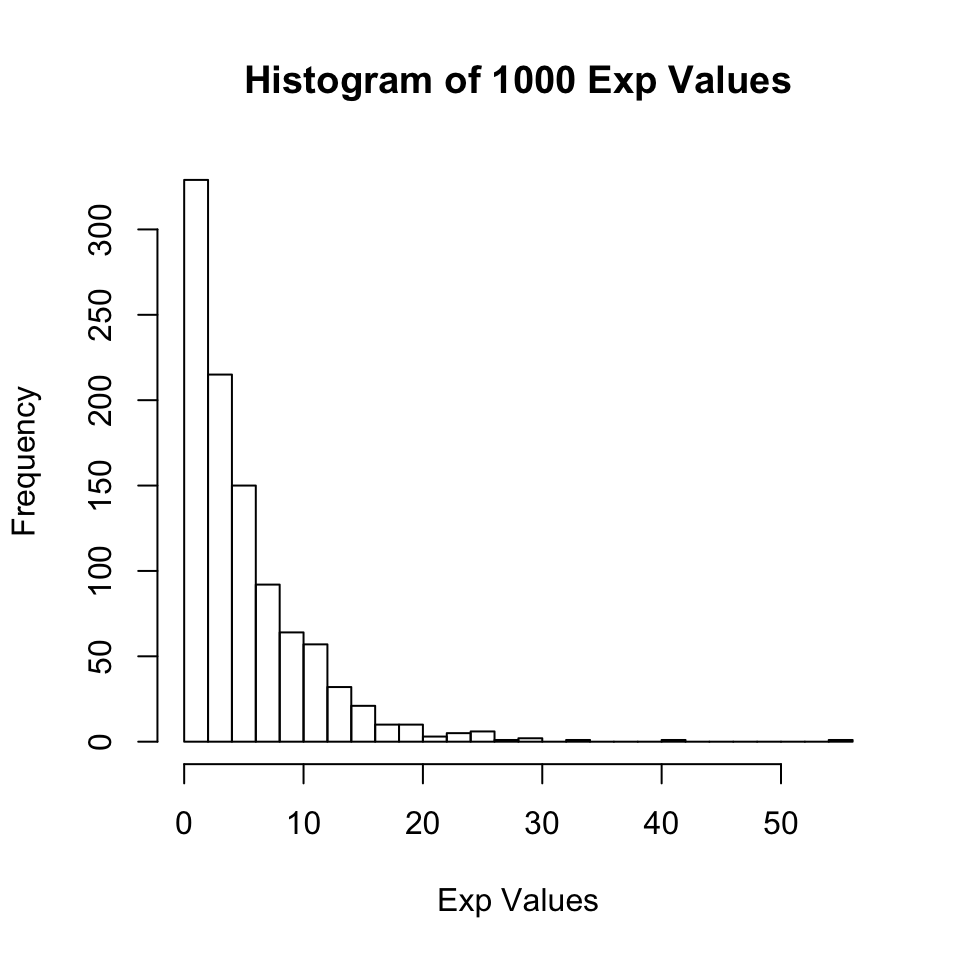

Then we’ll check the distribution of the means of 40 exponential values, running the simulation 1000 times

`r nosim = 1000; n = 40; lambda = 0.2; mean_values = NULL for(i in 1:nosim) mean_values = c(mean_values, mean(rexp(n,lambda))) hist(mean_values, breaks = 40, main = "Histogram of Mean Values", xlab = "Mean Exp Values")`

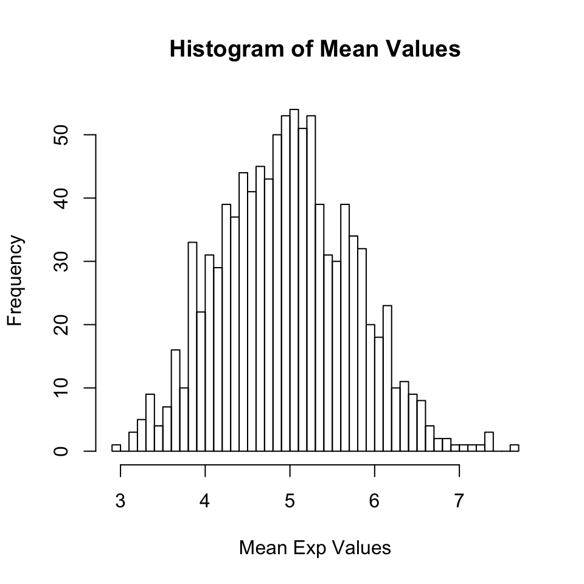

The theoretical variance of the distribution of means should be the squared of the standard error of the sample, which is just the variance divided by n squared.

```r
expdist <- var(rexp(1000,0.2)); mndisvar <- expdist/1000^2
```